# Music Genre Classification

CSC570AH Final Project

Devon Hunter

The goal of this project is to identify music genres using aural attributes of songs. The data has been provided and classified by Spotify. The dataset and attribute descriptions can be found using the links below:

- [Spotify Features Dataset](https://www.kaggle.com/zaheenhamidani/ultimate-spotify-tracks-db/version/2)
- [Spotify Features Description](https://developer.spotify.com/documentation/web-api/reference/tracks/get-audio-features/)

The original dataset used UTF-8-BOM encoding, which is not agreeable with knitr. The copy of the dataset included with this project was saved using standard UTF-8 encoding in Notepad++. No data was lost or altered.

```r
music.dataset <- read.csv("SpotifyFeatures.csv")
options(scipen = 5)
```

## 1. Exploratory Data Analysis and Preparation

The structure and summary of the dataset are shown below. We have 7 categorical variables and 11 numerical variables. There are 228,159 observations and no missing values:

```r
str(music.dataset)
```

```
'data.frame':   228159 obs. of  18 variables:
 $ genre           : Factor w/ 26 levels "A Capella","Alternative",..: 16 16 16 16 16 16 16 16 16 16 ...
 $ artist_name     : Factor w/ 13318 levels "'Til Tuesday",..: 4461 4404 4404 4461 4461 4461 4373 4461 12764 6759 ...
 $ track_name      : Factor w/ 130254 levels "' Cello Song",..: 102651 67511 118402 91385 29569 24533 123152 1604 51149 61033 ...
 $ track_id        : Factor w/ 153685 levels "000CzNKC8PEt1yC3L8dqwV",..: 144355 149148 150332 825 1205 7097 19712 27960 42195 65414 ...
 $ popularity      : int  21 18 10 17 19 20 13 19 20 16 ...
 $ acousticness    : num  0.986 0.972 0.935 0.961 0.985 0.99 0.98 0.975 0.951 0.968 ...
 $ danceability    : num  0.313 0.36 0.168 0.25 0.142 0.211 0.341 0.109 0.169 0.25 ...
 $ duration_ms     : int  490867 176797 266184 288573 629760 334720 646813 963440 417987 373480 ...
 $ energy          : num  0.231 0.201 0.47 0.00605 0.058 0.064 0.16 0.018 0.178 0.12 ...
 $ instrumentalness: num  0.000431 0.028 0.0204 0 0.146 0.0196 0.0146 0.791 0.185 0.0000492 ...
 $ key             : Factor w/ 12 levels "A","A#","B","C",..: 5 7 4 6 6 12 6 10 4 3 ...
 $ liveness        : num  0.0964 0.133 0.363 0.12 0.0969 0.073 0.113 0.0712 0.665 0.0865 ...
 $ loudness        : num  -14.29 -19.79 -8.41 -33.44 -23.62 ...
 $ mode            : Factor w/ 2 levels "Major","Minor": 1 1 1 1 1 1 1 1 2 1 ...
 $ speechiness     : num  0.0547 0.0581 0.0383 0.048 0.0493 0.0534 0.0575 0.0399 0.054 0.0654 ...
 $ tempo           : num  86 131.8 75.1 76.5 172.9 ...
 $ time_signature  : Factor w/ 5 levels "0/4","1/4","3/4",..: 4 4 3 4 4 3 2 4 4 4 ...
 $ valence         : num  0.0886 0.369 0.0696 0.038 0.0382 0.04 0.3 0.0359 0.112 0.0384 ...
```

```r
summary(music.dataset)
```

```
        genre                         artist_name       track_name                       track_id
 Comedy    :  9681   Giuseppe Verdi         :  1394   Home   :   111   0UE0RhnRaEYsiYgXpyLoZc:    10
 Soundtrack:  9646   Giacomo Puccini        :  1137   You    :    80   0wY9rA9fJkuESyYm9uzVK5:    10
 Indie     :  9543   Richard Wagner         :   804   Intro  :    68   3R73Y7X53MIQZWnKloWq5i:    10
 Jazz      :  9441   Wolfgang Amadeus Mozart:   800   Wake Up:    67   3uSSjnDMmoyERaAK9KvpJR:    10
 Pop       :  9386   Randy Newman           :   757   Stay   :    65   6AIte2Iej1QKlaofpjCzW1:    10
 Electronic:  9377   Georges Bizet          :   701   Closer :    63   6sVQNUvcVFTXvlk3ec0ngd:    10
 (Other)   :171085   (Other)                :222566   (Other):227705   (Other)               :228099
   popularity      acousticness       danceability     duration_ms          energy          instrumentalness
 Min.   :  0.00   Min.   :0.000001   Min.   :0.0569   Min.   :  15509   Min.   :0.0000203   Min.   :0.0000000
 1st Qu.: 33.00   1st Qu.:0.030900   1st Qu.:0.4370   1st Qu.: 186253   1st Qu.:0.4050000   1st Qu.:0.0000000
 Median : 47.00   Median :0.205000   Median :0.5700   Median : 221173   Median :0.6180000   Median :0.0000368
 Mean   : 44.21   Mean   :0.351200   Mean   :0.5542   Mean   : 236609   Mean   :0.5809669   Mean   :0.1373097
 3rd Qu.: 57.00   3rd Qu.:0.689000   3rd Qu.:0.6900   3rd Qu.: 264840   3rd Qu.:0.7930000   3rd Qu.:0.0234000
 Max.   :100.00   Max.   :0.996000   Max.   :0.9870   Max.   :5552917   Max.   :0.9990000   Max.   :0.9990000

      key           liveness          loudness          mode         speechiness         tempo        time_signature
 C      :26538   Min.   :0.00967   Min.   :-52.457   Major:147123   Min.   :0.0222   Min.   : 30.38   0/4:     8
 G      :25196   1st Qu.:0.09770   1st Qu.:-11.287   Minor: 81036   1st Qu.:0.0368   1st Qu.: 92.73   1/4:  2461
 C#     :23567   Median :0.12800   Median : -7.515                  Median :0.0506   Median :115.35   3/4: 22472
 D      :23196   Mean   :0.21464   Mean   : -9.355                  Mean   :0.1224   Mean   :117.42   4/4:198092
 A      :21925   3rd Qu.:0.26300   3rd Qu.: -5.415                  3rd Qu.:0.1090   3rd Qu.:138.89   5/4:  5126
 F      :19382   Max.   :1.00000   Max.   :  1.585                  Max.   :0.9670   Max.   :239.85
 (Other):88355
    valence
 Min.   :0.0000
 1st Qu.:0.2320
 Median :0.4300
 Mean   :0.4448
 3rd Qu.:0.6430
 Max.   :1.0000
```

Artist name, track name, and track id are removed because they are not relevant to music genre. Popularity might be useful, but it isn’t an aural attribute so it is also removed:

```r
music.dataset <- music.dataset[-c(2, 3, 4, 5)]
str(music.dataset)
```

```
'data.frame':   228159 obs. of  14 variables:
 $ genre           : Factor w/ 26 levels "A Capella","Alternative",..: 16 16 16 16 16 16 16 16 16 16 ...
 $ acousticness    : num  0.986 0.972 0.935 0.961 0.985 0.99 0.98 0.975 0.951 0.968 ...
 $ danceability    : num  0.313 0.36 0.168 0.25 0.142 0.211 0.341 0.109 0.169 0.25 ...
 $ duration_ms     : int  490867 176797 266184 288573 629760 334720 646813 963440 417987 373480 ...
 $ energy          : num  0.231 0.201 0.47 0.00605 0.058 0.064 0.16 0.018 0.178 0.12 ...
 $ instrumentalness: num  0.000431 0.028 0.0204 0 0.146 0.0196 0.0146 0.791 0.185 0.0000492 ...
 $ key             : Factor w/ 12 levels "A","A#","B","C",..: 5 7 4 6 6 12 6 10 4 3 ...
 $ liveness        : num  0.0964 0.133 0.363 0.12 0.0969 0.073 0.113 0.0712 0.665 0.0865 ...
 $ loudness        : num  -14.29 -19.79 -8.41 -33.44 -23.62 ...
 $ mode            : Factor w/ 2 levels "Major","Minor": 1 1 1 1 1 1 1 1 2 1 ...
 $ speechiness     : num  0.0547 0.0581 0.0383 0.048 0.0493 0.0534 0.0575 0.0399 0.054 0.0654 ...
 $ tempo           : num  86 131.8 75.1 76.5 172.9 ...
 $ time_signature  : Factor w/ 5 levels "0/4","1/4","3/4",..: 4 4 3 4 4 3 2 4 4 4 ...
 $ valence         : num  0.0886 0.369 0.0696 0.038 0.0382 0.04 0.3 0.0359 0.112 0.0384 ...
```

This project is not intended to be a comprehensive music genre classifier. The goal is to classify popular music genres; some of the more obscure genres are excluded:

```r
music.dataset <- music.dataset[music.dataset$genre != "A Capella", ]
music.dataset <- music.dataset[music.dataset$genre != "Anime", ]
music.dataset <- music.dataset[music.dataset$genre != "Childrenâ€™s Music", ]
music.dataset <- music.dataset[music.dataset$genre != "Comedy", ]
music.dataset <- music.dataset[music.dataset$genre != "Soundtrack", ]
music.dataset <- music.dataset[music.dataset$genre != "Movie", ]
music.dataset <- music.dataset[music.dataset$genre != "Opera", ]
music.dataset <- music.dataset[music.dataset$genre != "Reggaeton", ]
music.dataset <- music.dataset[music.dataset$genre != "World", ]
```

We’ll also remove subgenres to improve classification accuracy (e.g. R&B can be removed because it is a subgenre of blues):

```r
music.dataset <- music.dataset[music.dataset$genre != "R&B", ]
music.dataset <- music.dataset[music.dataset$genre != "Alternative", ]
music.dataset <- music.dataset[music.dataset$genre != "Indie", ]
music.dataset <- music.dataset[music.dataset$genre != "Ska", ]
music.dataset <- music.dataset[music.dataset$genre != "Dance", ]
music.dataset <- music.dataset[music.dataset$genre != "Soul", ]
music.dataset <- music.dataset[music.dataset$genre != "Rap", ]
music.dataset <- music.dataset[music.dataset$genre != "Reggae", ]
music.dataset <- droplevels(music.dataset)
```

The number of observations for each genre can be visualized using a barplot:

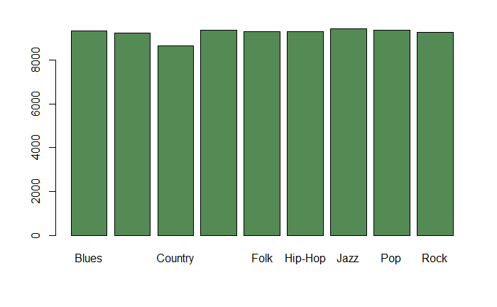

```r
barplot(table(music.dataset$genre), col = "palegreen4")
```

The dataset is downsampled for two reasons: first, we can make sure the classes are perfectly balanced. Second, we want to be able to train the classifiers in a reasonable amount of time. We can always adjust the sample rate in this section if the models show signs of overfitting.

The caret and dplyr packages are used to accomplish this. Caret’s downsample() function ensures the classes are evenly balanced and dplyr’s sample_frac() function samples 20% of each class. After downsampling we have 15,597 total observations, or 1,733 observations per class:

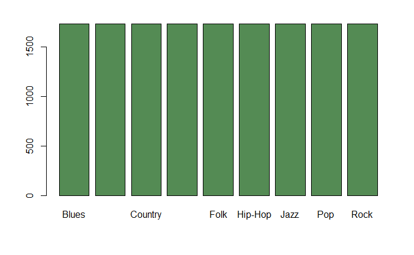

```r
library(ggplot2)
library(lattice)
library(caret)
library(dplyr, warn.conflicts = FALSE)
set.seed(1)
#Note: the class variable is moved to the last column
music.dataset <- downSample(music.dataset[ , -1],
                            music.dataset$genre,
                            list = FALSE,
                            yname = "genre")
set.seed(1)
music.dataset <- music.dataset %>% group_by(genre) %>% sample_frac(.2)
music.dataset <- as.data.frame(ungroup(music.dataset))
#We might lose some uncommon values (namely, instances where the time signature is 0/4),
#The factor levels are adjusted here to account for that
music.dataset <- droplevels(music.dataset)
barplot(table(music.dataset$genre), col = "palegreen4")
```

The relationships between the class variable and song attributes are explored here. First, nominal variable relationships are explored using heatmaps and chi-square tests:

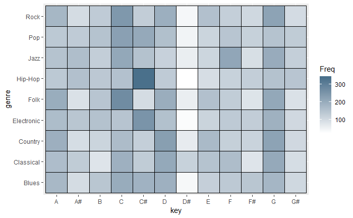

```r
attach(music.dataset, warn.conflicts = FALSE)
key.table <- table(key, genre)
mode.table <- table(mode, genre)
timesig.table <- table(time_signature, genre)
key.df <- as.data.frame(key.table)
mode.df <- as.data.frame(mode.table)
time.df <- as.data.frame(timesig.table)
ggplot(key.df, aes(key, genre)) + geom_tile(aes(fill = Freq), colour = "black") + scale_fill_gradient(low = "white", high = "skyblue4")
```

```r
chisq.test(key.table)
```

```
    Pearson's Chi-squared test

data:  key.table
X-squared = 769.15, df = 88, p-value < 2.2e-16
```

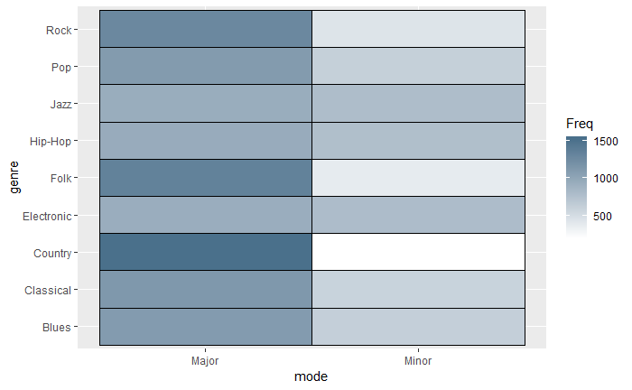

```r
ggplot(mode.df, aes(mode, genre)) + geom_tile(aes(fill = Freq), colour = "black") + scale_fill_gradient(low = "white", high = "skyblue4")
```

```r
chisq.test(mode.table)
```

```
    Pearson's Chi-squared test

data:  mode.table
X-squared = 846.87, df = 8, p-value < 2.2e-16
```

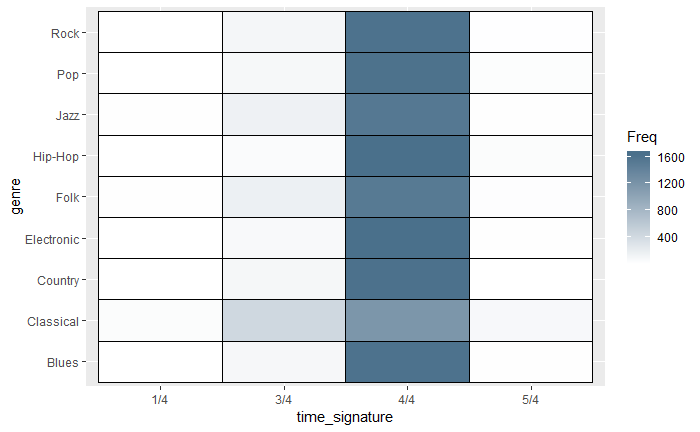

```r
ggplot(time.df, aes(time_signature, genre)) + geom_tile(aes(fill = Freq), colour = "black") + scale_fill_gradient(low = "white", high = "skyblue4")
```

```r
chisq.test(timesig.table)
```

```
    Pearson's Chi-squared test

data:  timesig.table
X-squared = 1125.1, df = 24, p-value < 2.2e-16
```

Based on the heatmaps, it looks like certain genres tend to prefer certain keys. Most genres use major modes and 4/4 time, but some make use of minor modes and odd time signatures.

The chi-square test results show very small p-values indicating a relationship between the class variable and key, mode, and time signature.

Next, the numeric attributes are explored using side-by-side boxplots and ANOVA tests.

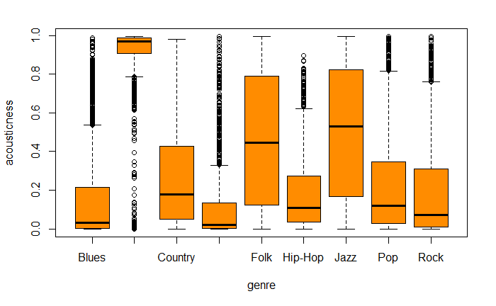

```r
plot(acousticness~genre, col="darkorange")
```

```r
oneway.test(acousticness~genre, data = music.dataset)
```

```
    One-way analysis of means (not assuming equal variances)

data:  acousticness and genre
F = 1560.2, num df = 8.0, denom df = 6481.8, p-value < 2.2e-16
```

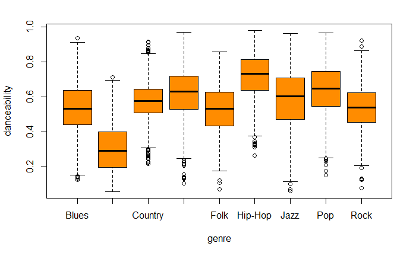

```r
plot(danceability~genre, col="darkorange")
```

```r
oneway.test(danceability~genre, data = music.dataset)
```

```
    One-way analysis of means (not assuming equal variances)

data:  danceability and genre
F = 1245.5, num df = 8.0, denom df = 6489.6, p-value < 2.2e-16
```

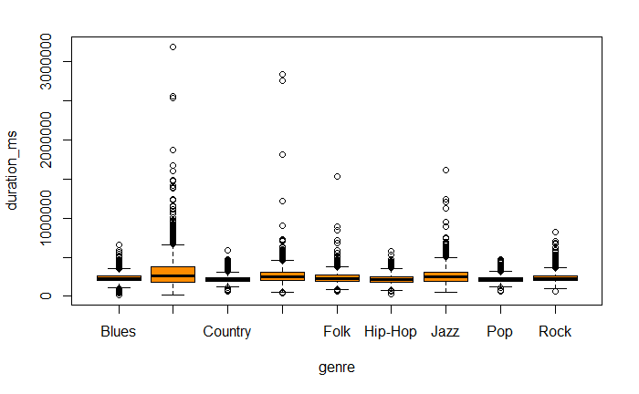

```r
plot(duration_ms~genre, col="darkorange")
```

```r
oneway.test(duration_ms~genre, data = music.dataset)
```

```
    One-way analysis of means (not assuming equal variances)

data:  duration_ms and genre
F = 104.56, num df = 8.0, denom df = 6444.9, p-value < 2.2e-16
```

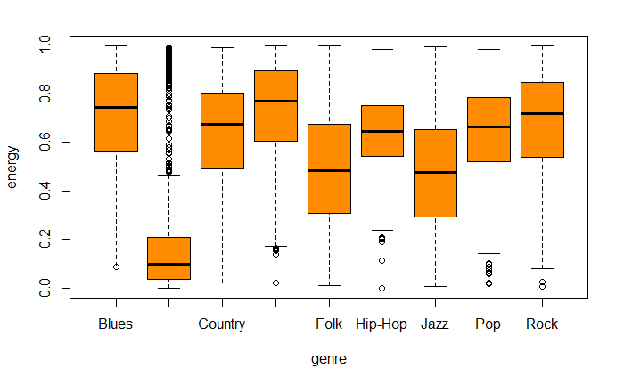

```r
plot(energy~genre, col="darkorange")
```

```r
oneway.test(energy~genre, data = music.dataset)
```

```
    One-way analysis of means (not assuming equal variances)

data:  energy and genre
F = 1062.1, num df = 8.0, denom df = 6485.4, p-value < 2.2e-16
```

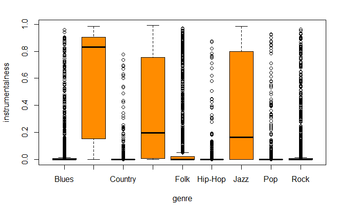

```r
plot(instrumentalness~genre, col="darkorange")
```

```r
oneway.test(instrumentalness~genre, data = music.dataset)
```

```
    One-way analysis of means (not assuming equal variances)

data:  instrumentalness and genre
F = 905.37, num df = 8.0, denom df = 6357.9, p-value < 2.2e-16
```

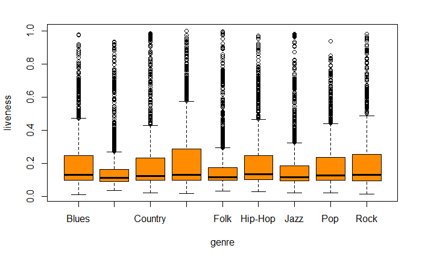

```r
plot(liveness~genre, col="darkorange")
```

```r
oneway.test(liveness~genre, data = music.dataset)
```

```
    One-way analysis of means (not assuming equal variances)

data:  liveness and genre
F = 14.752, num df = 8.0, denom df = 6493.4, p-value < 2.2e-16
```

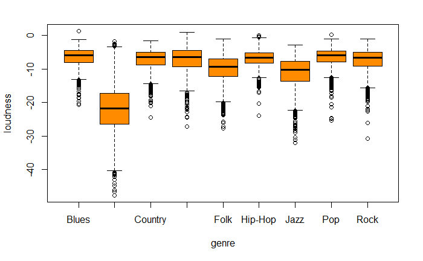

```r
plot(loudness~genre, col="darkorange")
```

```r
oneway.test(loudness~genre, data = music.dataset)
```

```
    One-way analysis of means (not assuming equal variances)

data:  loudness and genre
F = 984.83, num df = 8.0, denom df = 6470.1, p-value < 2.2e-16
```

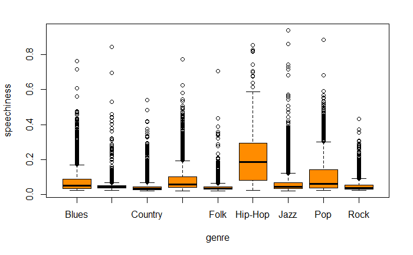

```r
plot(speechiness~genre, col="darkorange")
```

```r
oneway.test(speechiness~genre, data = music.dataset)
```

```
    One-way analysis of means (not assuming equal variances)

data:  speechiness and genre
F = 411.04, num df = 8.0, denom df = 6432.7, p-value < 2.2e-16
```

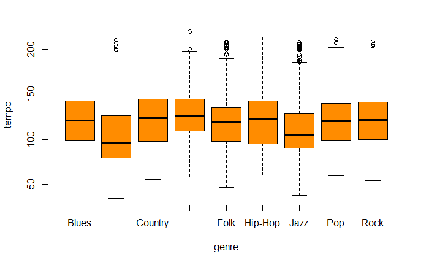

```r
plot(tempo~genre, col="darkorange")
```

```r
oneway.test(tempo~genre, data = music.dataset)
```

```
    One-way analysis of means (not assuming equal variances)

data:  tempo and genre
F = 95.532, num df = 8, denom df = 6494, p-value < 2.2e-16
```

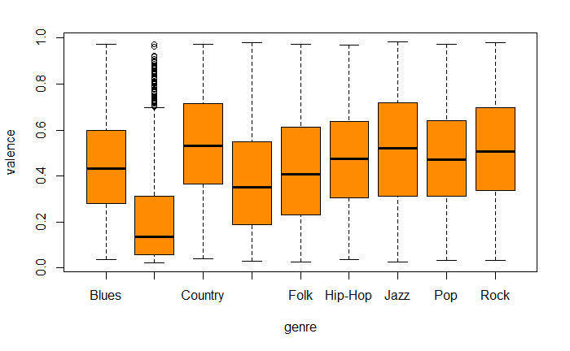

```r
plot(valence~genre, col="darkorange")
```

```r
oneway.test(valence~genre, data = music.dataset)
```

```
    One-way analysis of means (not assuming equal variances)

data:  valence and genre
F = 381.84, num df = 8.0, denom df = 6493.4, p-value < 2.2e-16
```

The box plots show a noticeable difference between the means of each attribute for each music genre. According to the ANOVA test results, all the numeric variables are significant.

Additional data preparation (i.e. normalization, encoding, etc.) will be performed as required for each machine learning algorithm. Before experimenting with models, the row order is randomized and the data is partitioned into train and test sets using the caret package. We’ll use 90% of the data for training and 10% for testing:

```r
music.dataset <- music.dataset[sample(nrow(music.dataset), replace = FALSE), ]
attach(music.dataset, warn.conflicts = FALSE)
set.seed(1)
train.index <- createDataPartition(genre, p = 0.9, list = FALSE)
music.train <- music.dataset[train.index, ]
music.test <- music.dataset[-train.index, ]
```

## Classifying Music Genre using Machine Learning Models

The following models are trained and tested in this section:

- KNN
- SVM
- Random Forest
- Gradient Boosted Trees
- Neural Network with TensorFlow Backend

Models with hyper-parameters (except the neural network) are auto-tuned using cross-validation with the caret package. The neural network is tuned manually.

The performance of the classifiers is evaluated in the next section. The accuracy and AUC of each classifier is stored and presented in a table. The pROC library is used to calculate AUC because ROCR doesn’t support multi-class classification.

#### Classification Using KNN

Before running the KNN algorithm, the categorical variables (except genre) in the train and test sets are converted to numeric. The results are stored as music.train.num and music.test.num so we can reuse them for other classifiers that require numeric variables:

```r
music.train.num <- music.train
music.test.num <- music.test
factor.cols <- c("key", "mode", "time_signature")
music.train.num[factor.cols] <- lapply(music.train.num[factor.cols], as.numeric)
music.test.num[factor.cols] <- lapply(music.test.num[factor.cols], as.numeric)
music.train.num[, "mode"] <- ifelse(music.train.num$mode == 2, 1, 0)
music.test.num[, "mode"] <- ifelse(music.test.num$mode == 2, 1, 0)
```

Next, the variables are scaled. Acousticness, danceability, energy, instrumentalness liveness, speechiness, and valence are not scaled because their values are already between 0 and 1. We’ll use min-max normalization so the ranges of the variables are consistent:

```r
normalize <- function(x) {
  return ((x - min(x)) / (max(x) - min(x)))
}
scale.cols <- c(3, 6, 8, 11, 12)
music.train.num[scale.cols] <- lapply(music.train.num[scale.cols], normalize)
music.test.num[scale.cols] <- lapply(music.test.num[scale.cols], normalize)
str(music.train.num)
```

```
'data.frame':   14040 obs. of  14 variables:
 $ acousticness    : num  0.924 0.909 0.00301 0.0637 0.022 0.118 0.991 0.446 0.0328 0.758 ...
 $ danceability    : num  0.578 0.298 0.693 0.809 0.592 0.524 0.273 0.297 0.562 0.561 ...
 $ duration_ms     : num  0.1333 0.1198 0.0641 0.0765 0.0681 ...
 $ energy          : num  0.227 0.124 0.87 0.688 0.729 0.853 0.0511 0.565 0.823 0.408 ...
 $ instrumentalness: num  0.59 0.0000841 0.631 0.793 0 0.212 0.92 0.00039 0.00000163 0.0000114 ...
 $ key             : num  0.364 0.364 0.909 0.364 1 ...
 $ liveness        : num  0.0846 0.295 0.155 0.0773 0.0653 0.0914 0.0697 0.103 0.212 0.0986 ...
 $ loudness        : num  0.619 0.628 0.894 0.854 0.888 ...
 $ mode            : num  0 0 0 0 0 1 0 0 0 0 ...
 $ speechiness     : num  0.0367 0.0504 0.0549 0.0554 0.0448 0.0647 0.0417 0.0305 0.0405 0.043 ...
 $ tempo           : num  0.269 0.279 0.588 0.421 0.454 ...
 $ time_signature  : num  0.333 0.333 0.667 0.667 0.667 ...
 $ valence         : num  0.229 0.146 0.693 0.732 0.709 0.138 0.0949 0.377 0.376 0.244 ...
 $ genre           : Factor w/ 9 levels "Blues","Classical",..: 7 2 4 7 8 4 2 3 3 5 ...
```

```r
str(music.test.num)
```

```
'data.frame':   1557 obs. of  14 variables:
 $ acousticness    : num  0.271 0.857 0.936 0.967 0.135 0.051 0.355 0.00558 0.129 0.046 ...
 $ danceability    : num  0.784 0.657 0.296 0.503 0.487 0.729 0.679 0.784 0.853 0.399 ...
 $ duration_ms     : num  0.1134 0.0627 0.0709 0.0581 0.1064 ...
 $ energy          : num  0.384 0.32 0.0417 0.304 0.573 0.928 0.804 0.586 0.637 0.781 ...
 $ instrumentalness: num  0.00193 0.00125 0.782 0 0.237 0.00127 0 0.000286 0 0.0552 ...
 $ key             : num  1 0.364 1 0.545 0.364 ...
 $ liveness        : num  0.0687 0.144 0.0833 0.646 0.295 0.199 0.0828 0.106 0.267 0.105 ...
 $ loudness        : num  0.819 0.691 0.382 0.71 0.801 ...
 $ mode            : num  0 0 0 0 0 1 0 0 1 0 ...
 $ speechiness     : num  0.0536 0.031 0.0678 0.151 0.088 0.165 0.0332 0.187 0.331 0.0925 ...
 $ tempo           : num  0.49 0.388 0.423 0.767 0.413 ...
 $ time_signature  : num  0.667 0.667 1 0.333 0.667 ...
 $ valence         : num  0.837 0.39 0.0574 0.813 0.144 0.758 0.822 0.656 0.496 0.691 ...
 $ genre           : Factor w/ 9 levels "Blues","Classical",..: 9 9 2 2 4 7 3 1 8 3 ...
```

With the preprocessing complete we can fit the KNN classifier. The classifier is tuned using values between 1 and the square root of the number of observations in the training set (~119):

```r
library(pROC, warn.conflicts = FALSE)
set.seed(1)
t.grid <- expand.grid(k = c(1, 5, 11, 25, 51, 76, 101, 119))
knn.model <- train(genre ~ ., data = music.train.num,
             trControl = trainControl(method = "cv", number = 10),
             tuneGrid = t.grid,
             method = "knn")
knn.model
```

```
k-Nearest Neighbors

14040 samples
   13 predictor
    9 classes: 'Blues', 'Classical', 'Country', 'Electronic', 'Folk', 'Hip-Hop', 'Jazz', 'Pop', 'Rock'

No pre-processing
Resampling: Cross-Validated (10 fold)
Summary of sample sizes: 12636, 12636, 12636, 12636, 12636, 12636, ...
Resampling results across tuning parameters:

  k    Accuracy   Kappa
    1  0.3245726  0.2401442
    5  0.3704416  0.2917468
   11  0.3919516  0.3159455
   25  0.4047721  0.3303686
   51  0.4111111  0.3375000
   76  0.4082621  0.3342949
  101  0.4066239  0.3324519
  119  0.4034188  0.3288462

Accuracy was used to select the optimal model using the largest value.
The final value used for the model was k = 51.
```

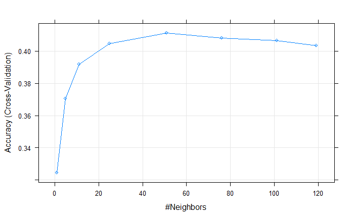

```r
plot(knn.model)
```

```r
predictions <- predict(knn.model, music.test.num)
c.matrix <- confusionMatrix(predictions, music.test.num$genre)
c.matrix
```

```
Confusion Matrix and Statistics

            Reference
Prediction   Blues Classical Country Electronic Folk Hip-Hop Jazz Pop Rock
  Blues         64         5      14         23   12       7    4  22   36
  Classical      2       148       1          2   10       0   19   0    2
  Country       25         0     107         12   42      22   13  41   52
  Electronic     9         4       1         70    7      10   19   5   11
  Folk          17        12      19          3   53       4   26  15   21
  Hip-Hop       17         0       7         22    3     101   12  41    6
  Jazz           6         2       5         15   18       5   61   3    4
  Pop           15         0       6         12   17      20    9  30   15
  Rock          18         2      13         14   11       4   10  16   26

Overall Statistics

               Accuracy : 0.4239
                 95% CI : (0.3992, 0.4489)
    No Information Rate : 0.1111
    P-Value [Acc > NIR] : < 2.2e-16

                  Kappa : 0.3519
 Mcnemar's Test P-Value : NA

Statistics by Class:

                     Class: Blues Class: Classical Class: Country Class: Electronic Class: Folk Class: Hip-Hop
Sensitivity                0.3699          0.85549        0.61850           0.40462     0.30636        0.58382
Specificity                0.9111          0.97399        0.85043           0.95231     0.91546        0.92197
Pos Pred Value             0.3422          0.80435        0.34076           0.51471     0.31176        0.48325
Neg Pred Value             0.9204          0.98179        0.94690           0.92752     0.91348        0.94659
Prevalence                 0.1111          0.11111        0.11111           0.11111     0.11111        0.11111
Detection Rate             0.0411          0.09505        0.06872           0.04496     0.03404        0.06487
Detection Prevalence       0.1201          0.11818        0.20167           0.08735     0.10918        0.13423
Balanced Accuracy          0.6405          0.91474        0.73447           0.67847     0.61091        0.75289
                     Class: Jazz Class: Pop Class: Rock
Sensitivity              0.35260    0.17341     0.15029
Specificity              0.95809    0.93208     0.93642
Pos Pred Value           0.51261    0.24194     0.22807
Neg Pred Value           0.92211    0.90021     0.89813
Prevalence               0.11111    0.11111     0.11111
Detection Rate           0.03918    0.01927     0.01670
Detection Prevalence     0.07643    0.07964     0.07322
Balanced Accuracy        0.65535    0.55275     0.54335
```

```r
knn.accuracy <- c.matrix$overall[1]
knn.auc <- multiclass.roc(as.numeric(music.test.num$genre), as.numeric(predictions))$auc[1]
```

#### Classification Using SVM

##### Linear Kernel

```r
set.seed(1)
t.grid <- expand.grid(C = c(.5, 1, 3, 5))
svm.lin.model <- train(genre ~ ., data = music.train.num,
             trControl = trainControl(method = "cv", number = 10),
             tuneGrid = t.grid,
             method = "svmLinear")
svm.lin.model
```

```
Support Vector Machines with Linear Kernel

14040 samples
   13 predictor
    9 classes: 'Blues', 'Classical', 'Country', 'Electronic', 'Folk', 'Hip-Hop', 'Jazz', 'Pop', 'Rock'

No pre-processing
Resampling: Cross-Validated (10 fold)
Summary of sample sizes: 12636, 12636, 12636, 12636, 12636, 12636, ...
Resampling results across tuning parameters:

  C    Accuracy   Kappa
  0.5  0.4481481  0.3791667
  1.0  0.4481481  0.3791667
  3.0  0.4481481  0.3791667
  5.0  0.4482194  0.3792468

Accuracy was used to select the optimal model using the largest value.
The final value used for the model was C = 5.
```

```r
predictions <- predict(svm.lin.model, music.test.num)
c.matrix <- confusionMatrix(predictions, music.test.num$genre)
c.matrix
```

```
Confusion Matrix and Statistics

            Reference
Prediction   Blues Classical Country Electronic Folk Hip-Hop Jazz Pop Rock
  Blues         68         6      15         20    8       5    5  18   35
  Classical      0       147       0          2    6       0   12   0    0
  Country       25         0     102          4   37      13    9  42   47
  Electronic    11         4       2         81    6       8   19   6   11
  Folk          10         8      22          3   57       1   28   7   24
  Hip-Hop       15         0       4         20    1      96   11  35    3
  Jazz          10         6       5         22   23       3   72   2   10
  Pop           21         0      13         17   17      47   13  54   17
  Rock          13         2      10          4   18       0    4   9   26

Overall Statistics

               Accuracy : 0.4515
                 95% CI : (0.4266, 0.4766)
    No Information Rate : 0.1111
    P-Value [Acc > NIR] : < 2.2e-16

                  Kappa : 0.3829
 Mcnemar's Test P-Value : NA

Statistics by Class:

                     Class: Blues Class: Classical Class: Country Class: Electronic Class: Folk Class: Hip-Hop
Sensitivity               0.39306          0.84971        0.58960           0.46821     0.32948        0.55491
Specificity               0.91908          0.98555        0.87211           0.95159     0.92558        0.93569
Pos Pred Value            0.37778          0.88024        0.36559           0.54730     0.35625        0.51892
Neg Pred Value            0.92375          0.98129        0.94444           0.93471     0.91696        0.94388
Prevalence                0.11111          0.11111        0.11111           0.11111     0.11111        0.11111
Detection Rate            0.04367          0.09441        0.06551           0.05202     0.03661        0.06166
Detection Prevalence      0.11561          0.10726        0.17919           0.09505     0.10276        0.11882
Balanced Accuracy         0.65607          0.91763        0.73085           0.70990     0.62753        0.74530
                     Class: Jazz Class: Pop Class: Rock
Sensitivity              0.41618    0.31214     0.15029
Specificity              0.94147    0.89523     0.95665
Pos Pred Value           0.47059    0.27136     0.30233
Neg Pred Value           0.92806    0.91237     0.90007
Prevalence               0.11111    0.11111     0.11111
Detection Rate           0.04624    0.03468     0.01670
Detection Prevalence     0.09827    0.12781     0.05523
Balanced Accuracy        0.67883    0.60368     0.55347
```

```r
svm.lin.accuracy <- c.matrix$overall[1]
svm.lin.auc <- multiclass.roc(as.numeric(music.test.num$genre), as.numeric(predictions))$auc[1]
```

##### Radial Kernel

```r
set.seed(1)
svm.rad.model <- train(genre ~ ., data = music.train.num,
             trControl = trainControl(method = "cv", number = 10),
             method = "svmRadial")
svm.rad.model
```

```
Support Vector Machines with Radial Basis Function Kernel

14040 samples
   13 predictor
    9 classes: 'Blues', 'Classical', 'Country', 'Electronic', 'Folk', 'Hip-Hop', 'Jazz', 'Pop', 'Rock'

No pre-processing
Resampling: Cross-Validated (10 fold)
Summary of sample sizes: 12636, 12636, 12636, 12636, 12636, 12636, ...
Resampling results across tuning parameters:

  C     Accuracy   Kappa
  0.25  0.4553419  0.3872596
  0.50  0.4606838  0.3932692
  1.00  0.4664530  0.3997596

Tuning parameter 'sigma' was held constant at a value of 0.06630039
Accuracy was used to select the optimal model using the largest value.
The final values used for the model were sigma = 0.06630039 and C = 1.
```

```r
predictions <- predict(svm.rad.model, music.test.num)
c.matrix <- confusionMatrix(predictions, music.test.num$genre)
c.matrix
```

```
Confusion Matrix and Statistics

            Reference
Prediction   Blues Classical Country Electronic Folk Hip-Hop Jazz Pop Rock
  Blues         69         4      13         20   11       5    5  21   38
  Classical      1       151       1          1    4       0   13   1    0
  Country       21         0      96          2   32       7    5  35   42
  Electronic    11         3       2         92    6       6   20   8   12
  Folk          11         6      19          4   62       1   29  11   28
  Hip-Hop       21         1       5         19    4     118   12  47    5
  Jazz           9         6       5         18   26       2   74   2   13
  Pop           20         0      18         13   14      33    9  43   12
  Rock          10         2      14          4   14       1    6   5   23

Overall Statistics

               Accuracy : 0.4676
                 95% CI : (0.4425, 0.4927)
    No Information Rate : 0.1111
    P-Value [Acc > NIR] : < 2.2e-16

                  Kappa : 0.401
 Mcnemar's Test P-Value : 0.000000005079

Statistics by Class:

                     Class: Blues Class: Classical Class: Country Class: Electronic Class: Folk Class: Hip-Hop Class: Jazz
Sensitivity               0.39884          0.87283        0.55491           0.53179     0.35838        0.68208     0.42775
Specificity               0.91546          0.98483        0.89595           0.95087     0.92124        0.91763     0.94147
Pos Pred Value            0.37097          0.87791        0.40000           0.57500     0.36257        0.50862     0.47742
Neg Pred Value            0.92414          0.98412        0.94153           0.94202     0.91991        0.95849     0.92939
Prevalence                0.11111          0.11111        0.11111           0.11111     0.11111        0.11111     0.11111
Detection Rate            0.04432          0.09698        0.06166           0.05909     0.03982        0.07579     0.04753
Detection Prevalence      0.11946          0.11047        0.15414           0.10276     0.10983        0.14900     0.09955
Balanced Accuracy         0.65715          0.92883        0.72543           0.74133     0.63981        0.79986     0.68461
                     Class: Pop Class: Rock
Sensitivity             0.24855     0.13295
Specificity             0.91402     0.95954
Pos Pred Value          0.26543     0.29114
Neg Pred Value          0.90681     0.89851
Prevalence              0.11111     0.11111
Detection Rate          0.02762     0.01477
Detection Prevalence    0.10405     0.05074
Balanced Accuracy       0.58129     0.54624
```

```r
svm.rad.accuracy <- c.matrix$overall[1]
svm.rad.auc <- multiclass.roc(as.numeric(music.test.num$genre), as.numeric(predictions))$auc[1]
```

#### Classification Using Ensemble Learners

##### Random Forest

```r
set.seed(1)
t.grid <- expand.grid(mtry = c(1, 3, 6, 8, 11, 13))
rf.model <- train(genre ~ ., data = music.train,
                  trControl = trainControl(method = "cv", number = 10),
                  tuneGrid = t.grid,
                  method = "rf",
                  importance = T)
rf.model
```

```
Random Forest

14040 samples
   13 predictor
    9 classes: 'Blues', 'Classical', 'Country', 'Electronic', 'Folk', 'Hip-Hop', 'Jazz', 'Pop', 'Rock'

No pre-processing
Resampling: Cross-Validated (10 fold)
Summary of sample sizes: 12636, 12636, 12636, 12636, 12636, 12636, ...
Resampling results across tuning parameters:

  mtry  Accuracy   Kappa
   1    0.3706553  0.2919872
   3    0.4762821  0.4108173
   6    0.4760684  0.4105769
   8    0.4720798  0.4060897
  11    0.4718661  0.4058494
  13    0.4708689  0.4047276

Accuracy was used to select the optimal model using the largest value.
The final value used for the model was mtry = 3.
```

```r
varImp(rf.model)
```

```
rf variable importance

  variables are sorted by maximum importance across the classes
  only 20 most important variables shown (out of 25)
```

|  | Blues | Classical | Country | Electronic | Folk | Hip-Hop | Jazz | Pop | Rock |
| --- | --- | --- | --- | --- | --- | --- | --- | --- | --- |
| instrumentalness | 24.633882 | 55.905764 | 91.911015 | 100.000000 | 25.101789 | 88.120826 | 70.858850 | 72.589309 | 16.335590 |
| speechiness | 16.264918 | 46.109175 | 80.962083 | 37.424033 | 55.404573 | 95.768106 | 23.619932 | 7.882025 | 27.007879 |
| danceability | 39.651979 | 76.504204 | 53.934547 | 46.994912 | 18.817592 | 70.142904 | 24.790068 | 17.406322 | 20.636220 |
| loudness | 36.224889 | 63.878561 | 36.508503 | 45.907923 | 22.289845 | 34.350848 | 35.334210 | 42.237709 | 0.000000 |
| acousticness | 59.705713 | 62.357800 | 37.044346 | 62.120169 | 26.982921 | 44.157723 | 31.854531 | 17.386838 | 17.332263 |
| energy | 34.948730 | 44.869679 | 45.602986 | 56.942082 | 24.577570 | 37.632037 | 27.267519 | 5.776222 | 19.197626 |
| modeMinor | 6.270227 | 8.421440 | 51.462768 | 21.106146 | 17.205127 | 12.801642 | 23.873357 | 3.606017 | 6.399784 |
| duration_ms | 11.560555 | 31.269801 | 49.289853 | 37.662238 | 10.336883 | 15.742881 | 32.539817 | 24.818029 | 2.818784 |
| valence | 17.908903 | 35.540285 | 46.527056 | 36.927064 | 15.755881 | 12.700287 | 46.053555 | 8.712953 | 16.133957 |
| tempo | 9.145476 | 26.197567 | 28.207975 | 43.210448 | 10.643853 | 15.825453 | 32.460170 | 6.500252 | 0.371542 |

[output cut: 10 more lines]

```r
predictions <- predict(rf.model, music.test)
c.matrix <- confusionMatrix(predictions, music.test$genre)
c.matrix
```

```
Confusion Matrix and Statistics

            Reference
Prediction   Blues Classical Country Electronic Folk Hip-Hop Jazz Pop Rock
  Blues         61         7       8         10   15      10    2   9   43
  Classical      0       153       1          2    5       0   15   0    0
  Country       24         1      98          3   31       5    3  34   43
  Electronic    14         4       3        109    8       6   27  11   14
  Folk          15         6      28          5   70       1   26  19   32
  Hip-Hop       23         1       9         13    4     117   12  51    5
  Jazz           5         1       3         23   24       4   77   1    8
  Pop           11         0      12          5    4      29    7  34    7
  Rock          20         0      11          3   12       1    4  14   21

Overall Statistics

               Accuracy : 0.4753
                 95% CI : (0.4502, 0.5004)
    No Information Rate : 0.1111
    P-Value [Acc > NIR] : < 2.2e-16

                  Kappa : 0.4097
 Mcnemar's Test P-Value : NA

Statistics by Class:

                     Class: Blues Class: Classical Class: Country Class: Electronic Class: Folk Class: Hip-Hop Class: Jazz
Sensitivity               0.35260          0.88439        0.56647           0.63006     0.40462        0.67630     0.44509
Specificity               0.92486          0.98338        0.89595           0.93714     0.90462        0.91474     0.95014
Pos Pred Value            0.36970          0.86932        0.40496           0.55612     0.34653        0.49787     0.52740
Neg Pred Value            0.91954          0.98552        0.94297           0.95298     0.92399        0.95764     0.93196
Prevalence                0.11111          0.11111        0.11111           0.11111     0.11111        0.11111     0.11111
Detection Rate            0.03918          0.09827        0.06294           0.07001     0.04496        0.07514     0.04945
Detection Prevalence      0.10597          0.11304        0.15543           0.12588     0.12974        0.15093     0.09377
Balanced Accuracy         0.63873          0.93389        0.73121           0.78360     0.65462        0.79552     0.69762
                     Class: Pop Class: Rock
Sensitivity             0.19653     0.12139
Specificity             0.94581     0.95303
Pos Pred Value          0.31193     0.24419
Neg Pred Value          0.90401     0.89667
Prevalence              0.11111     0.11111
Detection Rate          0.02184     0.01349
Detection Prevalence    0.07001     0.05523
Balanced Accuracy       0.57117     0.53721
```

```r
rf.accuracy <- c.matrix$overall[1]
rf.auc <- multiclass.roc(as.numeric(music.test$genre), as.numeric(predictions))$auc[1]
```

##### Gradient Boosted Trees

```r
set.seed(1)
gbm.model <- train(genre ~ ., data = music.train,
                  trControl = trainControl(method = "cv", number = 10),
                  method = "gbm",
                  verbose = FALSE)
gbm.model
```

```
Stochastic Gradient Boosting

14040 samples
   13 predictor
    9 classes: 'Blues', 'Classical', 'Country', 'Electronic', 'Folk', 'Hip-Hop', 'Jazz', 'Pop', 'Rock'

No pre-processing
Resampling: Cross-Validated (10 fold)
Summary of sample sizes: 12636, 12636, 12636, 12636, 12636, 12636, ...
Resampling results across tuning parameters:

  interaction.depth  n.trees  Accuracy   Kappa
  1                   50      0.4476496  0.3786058
  1                  100      0.4650285  0.3981571
  1                  150      0.4717949  0.4057692
  2                   50      0.4686610  0.4022436
  2                  100      0.4782051  0.4129808
  2                  150      0.4819801  0.4172276
  3                   50      0.4730769  0.4072115
  3                  100      0.4811254  0.4162660
  3                  150      0.4845442  0.4201122

Tuning parameter 'shrinkage' was held constant at a value of 0.1
Tuning parameter 'n.minobsinnode' was held
 constant at a value of 10
Accuracy was used to select the optimal model using the largest value.
The final values used for the model were n.trees = 150, interaction.depth = 3, shrinkage = 0.1 and n.minobsinnode
 = 10.
```

```r
predictions <- predict(gbm.model, music.test)
c.matrix <- confusionMatrix(predictions, music.test$genre)
c.matrix
```

```
Confusion Matrix and Statistics

            Reference
Prediction   Blues Classical Country Electronic Folk Hip-Hop Jazz Pop Rock
  Blues         57         4       8          8   11       4    0  17   29
  Classical      2       153       1          3    4       0   13   0    0
  Country       17         0      96          2   23       5    3  30   32
  Electronic    16         3       0        117    5      11   23  11   14
  Folk          20         6      20          3   77       2   27  15   35
  Hip-Hop       18         0       7         10    2     108   10  46    4
  Jazz           7         6       4         15   29       3   82   3   10
  Pop           17         0      18          9    8      38    8  43   12
  Rock          19         1      19          6   14       2    7   8   37

Overall Statistics

               Accuracy : 0.4945
                 95% CI : (0.4694, 0.5197)
    No Information Rate : 0.1111
    P-Value [Acc > NIR] : < 2.2e-16

                  Kappa : 0.4314
 Mcnemar's Test P-Value : NA

Statistics by Class:

                     Class: Blues Class: Classical Class: Country Class: Electronic Class: Folk Class: Hip-Hop
Sensitivity               0.32948          0.88439        0.55491           0.67630     0.44509        0.62428
Specificity               0.94147          0.98338        0.91908           0.94003     0.90751        0.92991
Pos Pred Value            0.41304          0.86932        0.46154           0.58500     0.37561        0.52683
Neg Pred Value            0.91825          0.98552        0.94292           0.95873     0.92899        0.95192
Prevalence                0.11111          0.11111        0.11111           0.11111     0.11111        0.11111
Detection Rate            0.03661          0.09827        0.06166           0.07514     0.04945        0.06936
Detection Prevalence      0.08863          0.11304        0.13359           0.12845     0.13166        0.13166
Balanced Accuracy         0.63548          0.93389        0.73699           0.80816     0.67630        0.77710
                     Class: Jazz Class: Pop Class: Rock
Sensitivity              0.47399    0.24855     0.21387
Specificity              0.94436    0.92052     0.94509
Pos Pred Value           0.51572    0.28105     0.32743
Neg Pred Value           0.93491    0.90741     0.90582
Prevalence               0.11111    0.11111     0.11111
Detection Rate           0.05267    0.02762     0.02376
Detection Prevalence     0.10212    0.09827     0.07258
Balanced Accuracy        0.70918    0.58454     0.57948
```

```r
gbm.accuracy <- c.matrix$overall[1]
gbm.auc <- multiclass.roc(as.numeric(music.test$genre), as.numeric(predictions))$auc[1]
```

#### Classification Using Neural Network

More data preparation is necessary before training the neural network. A single validation set is created from the training data since Keras doesn’t offer a convenient way to do cross-validation. The validation data will be used to tune the hyperparameters:

```r
set.seed(1)
in.train <- createDataPartition(music.train.num$genre, p = 0.9, list = FALSE)
music.train.nn <- as.data.frame(music.train.num[in.train, ])
music.validation.nn <- as.data.frame(music.train.num[-in.train, ])
```

The training, validation, and test labels are separated from the data. Keras’ to_categorical() function is used to one-hot encode the class labels:

```r
library(keras, warn.conflicts = FALSE)
music.train.labels <- to_categorical(as.numeric(music.train.nn$genre))
music.validation.labels <- to_categorical(as.numeric(music.validation.nn$genre))
music.test.labels <- as.numeric(music.test.num$genre)
#to_categorical adds a "0th" column that is removed:
music.train.labels <- music.train.labels[ , -1]
music.validation.labels <- music.validation.labels[ , -1]
music.train.nn <- as.matrix(music.train.nn[-14])
music.validation.nn <- as.matrix(music.validation.nn[-14])
music.test.nn <- as.matrix(music.test.num[-14])
```

The initial neural network is fit here. The categorical_crossentropy loss function and softmax activation function are most suitable for multi-class classification problems:

```r
model <- keras_model_sequential() %>%
  layer_dense(units = 9, activation = "softmax", input_shape = dim(music.train.nn)[2])
model %>% compile(loss = "categorical_crossentropy", optimizer = "sgd", metrics = "accuracy")
set.seed(1)
history <- model %>% fit(music.train.nn, music.train.labels,
                         batch_size = 64, epochs = 200,
                         verbose = 0,
                         validation_data = list(music.validation.nn, music.validation.labels))
```

```
2019-04-26 15:47:20.962702: I tensorflow/core/platform/cpu_feature_guard.cc:141] Your CPU supports instructions that this TensorFlow binary was not compiled to use: AVX AVX2
2019-04-26 15:47:20.964996: I tensorflow/core/common_runtime/process_util.cc:71] Creating new thread pool with default inter op setting: 4. Tune using inter_op_parallelism_threads for best performance.
```

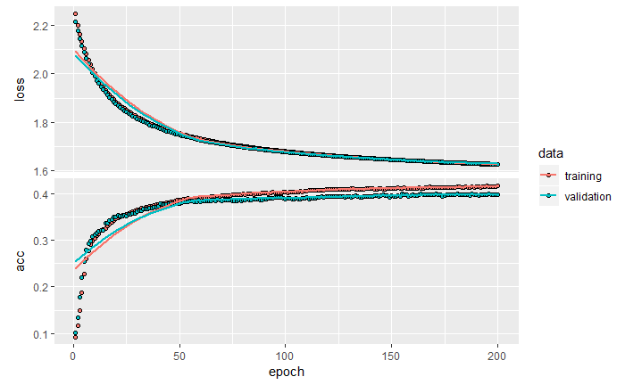

```r
plot(history)
```

Let’s try adding a hidden layer:

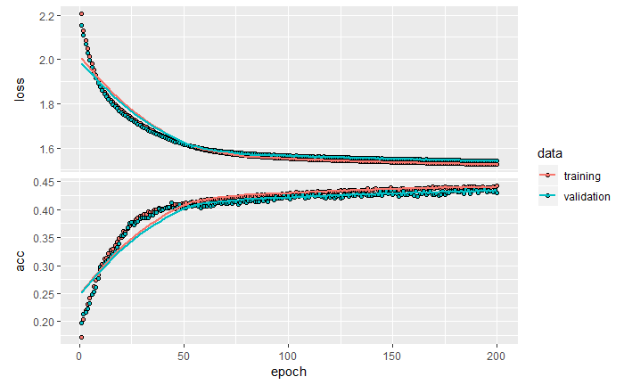

```r
model <- keras_model_sequential() %>%
  layer_dense(units = 11, activation = "relu", input_shape = dim(music.train.nn)[2]) %>%
  layer_dense(units = 9, activation = "softmax")
model %>% compile(loss = "categorical_crossentropy", optimizer = "sgd", metrics = "accuracy")
set.seed(1)
history <- model %>% fit(music.train.nn, music.train.labels,
                         batch_size = 64, epochs = 200,
                         verbose = 0,
                         validation_data = list(music.validation.nn, music.validation.labels))
plot(history)
```

Adding a hidden layer increases the accuracy a bit. We’ll keep the hidden layer and experiment with a few values for the number of neurons and the mini-batch size.

This model uses 11 neurons in the hidden layer and a mini-batch size of 32:

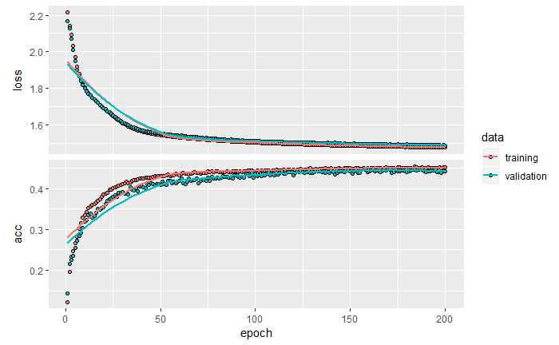

```r
model <- keras_model_sequential() %>%
  layer_dense(units = 11, activation = "relu", input_shape = dim(music.train.nn)[2]) %>%
  layer_dense(units = 9, activation = "softmax")
model %>% compile(loss = "categorical_crossentropy", optimizer = "sgd", metrics = "accuracy")
set.seed(1)
history <- model %>% fit(music.train.nn, music.train.labels,
                         batch_size = 32, epochs = 200,
                         verbose = 0,
                         validation_data = list(music.validation.nn, music.validation.labels))
plot(history)
```

This model uses 40 neurons and a mini-batch size of 64:

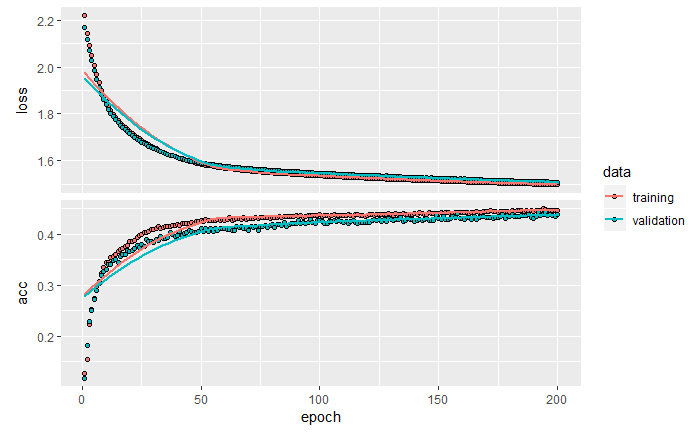

```r
model <- keras_model_sequential() %>%
  layer_dense(units = 40, activation = "relu", input_shape = dim(music.train.nn)[2]) %>%
  layer_dense(units = 9, activation = "softmax")
model %>% compile(loss = "categorical_crossentropy", optimizer = "sgd", metrics = "accuracy")
set.seed(1)
history <- model %>% fit(music.train.nn, music.train.labels,
                         batch_size = 64, epochs = 200,
                         verbose = 0,
                         validation_data = list(music.validation.nn, music.validation.labels))
plot(history)
```

This model uses 40 neurons and a mini-batch size of 32:

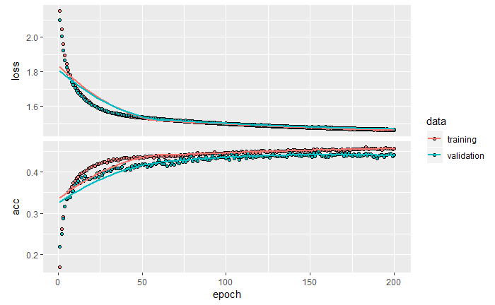

```r
model <- keras_model_sequential() %>%
  layer_dense(units = 40, activation = "relu", input_shape = dim(music.train.nn)[2]) %>%
  layer_dense(units = 9, activation = "softmax")
model %>% compile(loss = "categorical_crossentropy", optimizer = "sgd", metrics = "accuracy")
set.seed(1)
history <- model %>% fit(music.train.nn, music.train.labels,
                         batch_size = 32, epochs = 200,
                         verbose = 0,
                         validation_data = list(music.validation.nn, music.validation.labels))
plot(history)
```

We’ll use the last model to classify the test data. The predict() function returns a matrix of probabilities where each column corresponds to a genre. The column with the highest probability is selected as the class:

```r
predictions <- model %>% predict(music.test.nn)
predictions <- apply(predictions, 1, which.max)
c.matrix <- confusionMatrix(as.factor(predictions), as.factor(music.test.labels))
c.matrix
```

```
Confusion Matrix and Statistics

          Reference
Prediction   1   2   3   4   5   6   7   8   9
         1  59   4   6  17   6   3   4  13  27
         2   0 153   1   1   6   0  15   0   0
         3  25   0 104   4  50  16   7  36  53
         4  12   4   3  84   6   5  18   7  12
         5  14   4  21   4  49   1  24  12  25
         6  19   0   4  22   2 113  10  45   4
         7  12   6   6  18  28   5  79   5  10
         8  18   0  20  15  16  30  10  48  15
         9  14   2   8   8  10   0   6   7  27

Overall Statistics

               Accuracy : 0.4599
                 95% CI : (0.4349, 0.485)
    No Information Rate : 0.1111
    P-Value [Acc > NIR] : < 2.2e-16

                  Kappa : 0.3923
 Mcnemar's Test P-Value : NA

Statistics by Class:

                     Class: 1 Class: 2 Class: 3 Class: 4 Class: 5 Class: 6 Class: 7 Class: 8 Class: 9
Sensitivity           0.34104  0.88439   0.6012  0.48555  0.28324  0.65318  0.45665  0.27746  0.15607
Specificity           0.94220  0.98338   0.8620  0.95159  0.92413  0.92341  0.93497  0.91040  0.96026
Pos Pred Value        0.42446  0.86932   0.3525  0.55629  0.31818  0.51598  0.46746  0.27907  0.32927
Neg Pred Value        0.91961  0.98552   0.9453  0.93670  0.91162  0.95516  0.93228  0.90975  0.90102
Prevalence            0.11111  0.11111   0.1111  0.11111  0.11111  0.11111  0.11111  0.11111  0.11111
Detection Rate        0.03789  0.09827   0.0668  0.05395  0.03147  0.07258  0.05074  0.03083  0.01734
Detection Prevalence  0.08927  0.11304   0.1895  0.09698  0.09891  0.14066  0.10854  0.11047  0.05267
Balanced Accuracy     0.64162  0.93389   0.7316  0.71857  0.60368  0.78829  0.69581  0.59393  0.55816
```

```r
nn.accuracy <- c.matrix$overall[1]
nn.auc <- multiclass.roc(music.test.labels, predictions)$auc[1]
```

#### Results

The accuracy and AUC of each classifier is shown below:

```r
performance <- matrix(c(knn.accuracy, knn.auc,
                       svm.lin.accuracy, svm.lin.auc,
                       svm.rad.accuracy, svm.rad.auc,
                       rf.accuracy, rf.auc,
                       gbm.accuracy, gbm.auc,
                       nn.accuracy, nn.auc),
                     ncol = 2, byrow = TRUE)
colnames(performance) <- c("Accuracy", "AUC")
rownames(performance) <- c("KNN", "SVM Linear", "SVM Radial", "Random Forest", "GBM", "Neural Network")
as.table(performance)
```

```
                Accuracy       AUC
KNN            0.4238921 0.6406556
SVM Linear     0.4515093 0.6518580
SVM Radial     0.4675658 0.6513090
Random Forest  0.4752730 0.6684315
GBM            0.4945408 0.6569557
Neural Network 0.4598587 0.6529815
```

The models’ classification accuracy and AUC is not great, but acceptable considering the number of classes. GBM performed the best with a classification accuracy of ~49%. The random forest model performed nearly as well with accuracy of over 47% and AUC greater than GMB.